# W3cubDocs

/Qt

# QUrl Class

The QUrl class provides a convenient interface for working with URLs. More...

| Header: | #include <QUrl> |
| --- | --- |
| CMake: | find_package(Qt6 COMPONENTS Core REQUIRED) target_link_libraries(mytarget PRIVATE Qt6::Core) |
| qmake: | QT += core |

- [List of all members, including inherited members](https://doc.qt.io/qt-6.2/qurl-members.html)

**Note:** All functions in this class are reentrant.

## Public Types

| enum | **ComponentFormattingOption** { PrettyDecoded, EncodeSpaces, EncodeUnicode, EncodeDelimiters, EncodeReserved, …, FullyDecoded } |
| --- | --- |
| flags | **ComponentFormattingOptions** |
| flags | **FormattingOptions** |
| enum | **ParsingMode** { TolerantMode, StrictMode, DecodedMode } |
| enum | **UrlFormattingOption** { None, RemoveScheme, RemovePassword, RemoveUserInfo, RemovePort, …, NormalizePathSegments } |
| enum | **UserInputResolutionOption** { DefaultResolution, AssumeLocalFile } |
| flags | **UserInputResolutionOptions** |

## Public Functions

|  | **QUrl**(QUrl &&*other*) |
| --- | --- |
|  | **QUrl**(const QString &*url*, QUrl::ParsingMode *parsingMode* = TolerantMode) |
|  | **QUrl**(const QUrl &*other*) |
|  | **QUrl**() |
| QUrl & | **operator=**(QUrl &&*other*) |
| QUrl & | **operator=**(const QString &*url*) |
| QUrl & | **operator=**(const QUrl &*url*) |
|  | **~QUrl**() |
| QUrl | **adjusted**(QUrl::FormattingOptions *options*) const |
| QString | **authority**(QUrl::ComponentFormattingOptions *options* = PrettyDecoded) const |
| void | **clear**() |
| QString | **errorString**() const |
| QString | **fileName**(QUrl::ComponentFormattingOptions *options* = FullyDecoded) const |
| QString | **fragment**(QUrl::ComponentFormattingOptions *options* = PrettyDecoded) const |
| bool | **hasFragment**() const |
| bool | **hasQuery**() const |
| QString | **host**(QUrl::ComponentFormattingOptions *options* = FullyDecoded) const |
| bool | **isEmpty**() const |
| bool | **isLocalFile**() const |
| bool | **isParentOf**(const QUrl &*childUrl*) const |
| bool | **isRelative**() const |
| bool | **isValid**() const |
| bool | **matches**(const QUrl &*url*, QUrl::FormattingOptions *options*) const |
| QString | **password**(QUrl::ComponentFormattingOptions *options* = FullyDecoded) const |
| QString | **path**(QUrl::ComponentFormattingOptions *options* = FullyDecoded) const |
| int | **port**(int *defaultPort* = -1) const |
| QString | **query**(QUrl::ComponentFormattingOptions *options* = PrettyDecoded) const |
| QUrl | **resolved**(const QUrl &*relative*) const |
| QString | **scheme**() const |
| void | **setAuthority**(const QString &*authority*, QUrl::ParsingMode *mode* = TolerantMode) |
| void | **setFragment**(const QString &*fragment*, QUrl::ParsingMode *mode* = TolerantMode) |
| void | **setHost**(const QString &*host*, QUrl::ParsingMode *mode* = DecodedMode) |
| void | **setPassword**(const QString &*password*, QUrl::ParsingMode *mode* = DecodedMode) |
| void | **setPath**(const QString &*path*, QUrl::ParsingMode *mode* = DecodedMode) |
| void | **setPort**(int *port*) |
| void | **setQuery**(const QString &*query*, QUrl::ParsingMode *mode* = TolerantMode) |
| void | **setQuery**(const QUrlQuery &*query*) |
| void | **setScheme**(const QString &*scheme*) |
| void | **setUrl**(const QString &*url*, QUrl::ParsingMode *parsingMode* = TolerantMode) |
| void | **setUserInfo**(const QString &*userInfo*, QUrl::ParsingMode *mode* = TolerantMode) |
| void | **setUserName**(const QString &*userName*, QUrl::ParsingMode *mode* = DecodedMode) |
| void | **swap**(QUrl &*other*) |
| CFURLRef | **toCFURL**() const |
| QString | **toDisplayString**(QUrl::FormattingOptions *options* = FormattingOptions(PrettyDecoded)) const |
| QByteArray | **toEncoded**(QUrl::FormattingOptions *options* = FullyEncoded) const |
| QString | **toLocalFile**() const |
| NSURL * | **toNSURL**() const |
| QString | **toString**(QUrl::FormattingOptions *options* = FormattingOptions(PrettyDecoded)) const |
| QString | **url**(QUrl::FormattingOptions *options* = FormattingOptions(PrettyDecoded)) const |
| QString | **userInfo**(QUrl::ComponentFormattingOptions *options* = PrettyDecoded) const |
| QString | **userName**(QUrl::ComponentFormattingOptions *options* = FullyDecoded) const |
| bool | **operator!=**(const QUrl &*url*) const |
| bool | **operator==**(const QUrl &*url*) const |

## Static Public Members

| QString | **fromAce**(const QByteArray &*domain*) |
| --- | --- |
| QUrl | **fromCFURL**(CFURLRef *url*) |
| QUrl | **fromEncoded**(const QByteArray &*input*, QUrl::ParsingMode *parsingMode* = TolerantMode) |
| QUrl | **fromLocalFile**(const QString &*localFile*) |
| QUrl | **fromNSURL**(const NSURL **url*) |
| QString | **fromPercentEncoding**(const QByteArray &*input*) |
| QList<QUrl> | **fromStringList**(const QStringList &*urls*, QUrl::ParsingMode *mode* = TolerantMode) |
| QUrl | **fromUserInput**(const QString &*userInput*, const QString &*workingDirectory* = QString(), QUrl::UserInputResolutionOptions *options* = DefaultResolution) |
| QStringList | **idnWhitelist**() |
| void | **setIdnWhitelist**(const QStringList &*list*) |
| QByteArray | **toAce**(const QString &*domain*) |
| QByteArray | **toPercentEncoding**(const QString &*input*, const QByteArray &*exclude* = QByteArray(), const QByteArray &*include* = QByteArray()) |
| QStringList | **toStringList**(const QList<QUrl> &*urls*, QUrl::FormattingOptions *options* = FormattingOptions(PrettyDecoded)) |

## Related Non-Members

| QDataStream & | **operator<<**(QDataStream &*out*, const QUrl &*url*) |
| --- | --- |
| QDataStream & | **operator>>**(QDataStream &*in*, QUrl &*url*) |

## Macros

|  | **QT_NO_URL_CAST_FROM_STRING** |
| --- | --- |

## Detailed Description

It can parse and construct URLs in both encoded and unencoded form. QUrl also has support for internationalized domain names (IDNs).

The most common way to use QUrl is to initialize it via the constructor by passing a QString. Otherwise, setUrl() can also be used.

URLs can be represented in two forms: encoded or unencoded. The unencoded representation is suitable for showing to users, but the encoded representation is typically what you would send to a web server. For example, the unencoded URL "http://bühler.example.com/List of applicants.xml" would be sent to the server as "http://xn--bhler-kva.example.com/List%20of%20applicants.xml".

A URL can also be constructed piece by piece by calling setScheme(), setUserName(), setPassword(), setHost(), setPort(), setPath(), setQuery() and setFragment(). Some convenience functions are also available: setAuthority() sets the user name, password, host and port. setUserInfo() sets the user name and password at once.

Call isValid() to check if the URL is valid. This can be done at any point during the constructing of a URL. If isValid() returns `false`, you should clear() the URL before proceeding, or start over by parsing a new URL with setUrl().

Constructing a query is particularly convenient through the use of the QUrlQuery class and its methods QUrlQuery::setQueryItems(), QUrlQuery::addQueryItem() and QUrlQuery::removeQueryItem(). Use QUrlQuery::setQueryDelimiters() to customize the delimiters used for generating the query string.

For the convenience of generating encoded URL strings or query strings, there are two static functions called fromPercentEncoding() and toPercentEncoding() which deal with percent encoding and decoding of QString objects.

fromLocalFile() constructs a QUrl by parsing a local file path. toLocalFile() converts a URL to a local file path.

The human readable representation of the URL is fetched with toString(). This representation is appropriate for displaying a URL to a user in unencoded form. The encoded form however, as returned by toEncoded(), is for internal use, passing to web servers, mail clients and so on. Both forms are technically correct and represent the same URL unambiguously -- in fact, passing either form to QUrl's constructor or to setUrl() will yield the same QUrl object.

QUrl conforms to the URI specification from [RFC 3986](https://datatracker.ietf.org/doc/html/rfc3986) (Uniform Resource Identifier: Generic Syntax), and includes scheme extensions from [RFC 1738](https://datatracker.ietf.org/doc/html/rfc1738) (Uniform Resource Locators). Case folding rules in QUrl conform to [RFC 3491](https://datatracker.ietf.org/doc/html/rfc3491) (Nameprep: A Stringprep Profile for Internationalized Domain Names (IDN)). It is also compatible with the [file URI specification](http://freedesktop.org/wiki/Specifications/file-uri-spec/) from freedesktop.org, provided that the locale encodes file names using UTF-8 (required by IDN).

#### Relative URLs vs Relative Paths

Calling isRelative() will return whether or not the URL is relative. A relative URL has no scheme. For example:

```
    qDebug() << QUrl("main.qml").isRelative();          // true: no scheme
    qDebug() << QUrl("qml/main.qml").isRelative();      // true: no scheme
    qDebug() << QUrl("file:main.qml").isRelative();     // false: has "file" scheme
    qDebug() << QUrl("file:qml/main.qml").isRelative(); // false: has "file" scheme
```

Notice that a URL can be absolute while containing a relative path, and vice versa:

```
    // Absolute URL, relative path
    QUrl url("file:file.txt");
    qDebug() << url.isRelative();                 // false: has "file" scheme
    qDebug() << QDir::isAbsolutePath(url.path()); // false: relative path

    // Relative URL, absolute path
    url = QUrl("/home/user/file.txt");
    qDebug() << url.isRelative();                 // true: has no scheme
    qDebug() << QDir::isAbsolutePath(url.path()); // true: absolute path
```

A relative URL can be resolved by passing it as an argument to resolved(), which returns an absolute URL. isParentOf() is used for determining whether one URL is a parent of another.

#### Error checking

QUrl is capable of detecting many errors in URLs while parsing it or when components of the URL are set with individual setter methods (like setScheme(), setHost() or setPath()). If the parsing or setter function is successful, any previously recorded error conditions will be discarded.

By default, QUrl setter methods operate in QUrl::TolerantMode, which means they accept some common mistakes and mis-representation of data. An alternate method of parsing is QUrl::StrictMode, which applies further checks. See QUrl::ParsingMode for a description of the difference of the parsing modes.

QUrl only checks for conformance with the URL specification. It does not try to verify that high-level protocol URLs are in the format they are expected to be by handlers elsewhere. For example, the following URIs are all considered valid by QUrl, even if they do not make sense when used:

- "http:/filename.html"
- "mailto://example.com"

When the parser encounters an error, it signals the event by making isValid() return false and toString() / toEncoded() return an empty string. If it is necessary to show the user the reason why the URL failed to parse, the error condition can be obtained from QUrl by calling errorString(). Note that this message is highly technical and may not make sense to end-users.

QUrl is capable of recording only one error condition. If more than one error is found, it is undefined which error is reported.

#### Character Conversions

Follow these rules to avoid erroneous character conversion when dealing with URLs and strings:

- When creating a QString to contain a URL from a QByteArray or a char*, always use QString::fromUtf8().

## Member Type Documentation

### `[since 5.0]`enum QUrl::ComponentFormattingOptionflags QUrl::ComponentFormattingOptions

The component formatting options define how the components of an URL will be formatted when written out as text. They can be combined with the options from QUrl::FormattingOptions when used in toString() and toEncoded().

[output not shown]

The values of EncodeReserved and DecodeReserved should not be used together in one call. The behavior is undefined if that happens. They are provided as separate values because the behavior of the "pretty mode" with regards to reserved characters is different on certain components and specially on the full URL.

##### Full decoding

The FullyDecoded mode is similar to the behavior of the functions returning QString in Qt 4.x, in that every character represents itself and never has any special meaning. This is true even for the percent character ('%'), which should be interpreted to mean a literal percent, not the beginning of a percent-encoded sequence. The same actual character, in all other decoding modes, is represented by the sequence "%25".

Whenever re-applying data obtained with QUrl::FullyDecoded into a QUrl, care must be taken to use the QUrl::DecodedMode parameter to the setters (like setPath() and setUserName()). Failure to do so may cause re-interpretation of the percent character ('%') as the beginning of a percent-encoded sequence.

This mode is quite useful when portions of a URL are used in a non-URL context. For example, to extract the username, password or file paths in an FTP client application, the FullyDecoded mode should be used.

This mode should be used with care, since there are two conditions that cannot be reliably represented in the returned QString. They are:

- **Non-UTF-8 sequences:** URLs may contain sequences of percent-encoded characters that do not form valid UTF-8 sequences. Since URLs need to be decoded using UTF-8, any decoder failure will result in the QString containing one or more replacement characters where the sequence existed.
- **Encoded delimiters:** URLs are also allowed to make a distinction between a delimiter found in its literal form and its equivalent in percent-encoded form. This is most commonly found in the query, but is permitted in most parts of the URL.

The following example illustrates the problem:

```
    QUrl original("http://example.com/?q=a%2B%3Db%26c");
    QUrl copy(original);
    copy.setQuery(copy.query(QUrl::FullyDecoded), QUrl::DecodedMode);

    qDebug() << original.toString();   // prints: http://example.com/?q=a%2B%3Db%26c
    qDebug() << copy.toString();       // prints: http://example.com/?q=a+=b&c
```

If the two URLs were used via HTTP GET, the interpretation by the web server would probably be different. In the first case, it would interpret as one parameter, with a key of "q" and value "a+=b&c". In the second case, it would probably interpret as two parameters, one with a key of "q" and value "a =b", and the second with a key "c" and no value.

This enum was introduced or modified in Qt 5.0.

The ComponentFormattingOptions type is a typedef for QFlags<ComponentFormattingOption>. It stores an OR combination of ComponentFormattingOption values.

**See also** QUrl::FormattingOptions.

### enum QUrl::ParsingMode

The parsing mode controls the way QUrl parses strings.

[output not shown]

In TolerantMode, the parser has the following behaviour:

- Spaces and "%20": unencoded space characters will be accepted and will be treated as equivalent to "%20".
- Single "%" characters: Any occurrences of a percent character "%" not followed by exactly two hexadecimal characters (e.g., "13% coverage.html") will be replaced by "%25". Note that one lone "%" character will trigger the correction mode for all percent characters.
- Reserved and unreserved characters: An encoded URL should only contain a few characters as literals; all other characters should be percent-encoded. In TolerantMode, these characters will be accepted if they are found in the URL: space / double-quote / "<" / ">" / "" / "^" / "`" / "{" / "|" / "}" Those same characters can be decoded again by passing QUrl::DecodeReserved to toString() or toEncoded(). In the getters of individual components, those characters are often returned in decoded form.

When in StrictMode, if a parsing error is found, isValid() will return `false` and errorString() will return a message describing the error. If more than one error is detected, it is undefined which error gets reported.

Note that TolerantMode is not usually enough for parsing user input, which often contains more errors and expectations than the parser can deal with. When dealing with data coming directly from the user -- as opposed to data coming from data-transfer sources, such as other programs -- it is recommended to use fromUserInput().

**See also** fromUserInput(), setUrl(), toString(), toEncoded(), and QUrl::FormattingOptions.

### enum QUrl::UrlFormattingOptionflags QUrl::FormattingOptions

The formatting options define how the URL is formatted when written out as text.

| Constant | Value | Description |
| --- | --- | --- |
| `QUrl::None` | `0x0` | The format of the URL is unchanged. |
| `QUrl::RemoveScheme` | `0x1` | The scheme is removed from the URL. |
| `QUrl::RemovePassword` | `0x2` | Any password in the URL is removed. |
| `QUrl::RemoveUserInfo` | `RemovePassword \| 0x4` | Any user information in the URL is removed. |
| `QUrl::RemovePort` | `0x8` | Any specified port is removed from the URL. |
| `QUrl::RemoveAuthority` | `RemoveUserInfo \| RemovePort \| 0x10` |  |
| `QUrl::RemovePath` | `0x20` | The URL's path is removed, leaving only the scheme, host address, and port (if present). |
| `QUrl::RemoveQuery` | `0x40` | The query part of the URL (following a '?' character) is removed. |
| `QUrl::RemoveFragment` | `0x80` |  |
| `QUrl::RemoveFilename` | `0x800` | The filename (i.e. everything after the last '/' in the path) is removed. The trailing '/' is kept, unless StripTrailingSlash is set. Only valid if RemovePath is not set. |
| `QUrl::PreferLocalFile` | `0x200` | If the URL is a local file according to isLocalFile() and contains no query or fragment, a local file path is returned. |
| `QUrl::StripTrailingSlash` | `0x400` | The trailing slash is removed from the path, if one is present. |
| `QUrl::NormalizePathSegments` | `0x1000` | Modifies the path to remove redundant directory separators, and to resolve "."s and ".."s (as far as possible). For non-local paths, adjacent slashes are preserved. |

Note that the case folding rules in [Nameprep](https://datatracker.ietf.org/doc/html/rfc3491), which QUrl conforms to, require host names to always be converted to lower case, regardless of the Qt::FormattingOptions used.

The options from QUrl::ComponentFormattingOptions are also possible.

The FormattingOptions type is a typedef for QFlags<UrlFormattingOption>. It stores an OR combination of UrlFormattingOption values.

**See also** QUrl::ComponentFormattingOptions.

### `[since 5.4]`enum QUrl::UserInputResolutionOptionflags QUrl::UserInputResolutionOptions

The user input resolution options define how fromUserInput() should interpret strings that could either be a relative path or the short form of a HTTP URL. For instance `file.pl` can be either a local file or the URL `http://file.pl`.

[output not shown]

This enum was introduced or modified in Qt 5.4.

The UserInputResolutionOptions type is a typedef for QFlags<UserInputResolutionOption>. It stores an OR combination of UserInputResolutionOption values.

**See also** fromUserInput().

## Member Function Documentation

### `[since 5.2]`QUrl::QUrl(QUrl &&*other*)

Move-constructs a QUrl instance, making it point at the same object that *other* was pointing to.

This function was introduced in Qt 5.2.

### QUrl::QUrl(const QString &*url*, QUrl::ParsingMode *parsingMode* = TolerantMode)

Constructs a URL by parsing *url*. QUrl will automatically percent encode all characters that are not allowed in a URL and decode the percent-encoded sequences that represent an unreserved character (letters, digits, hyphens, underscores, dots and tildes). All other characters are left in their original forms.

Parses the *url* using the parser mode *parsingMode*. In TolerantMode (the default), QUrl will correct certain mistakes, notably the presence of a percent character ('%') not followed by two hexadecimal digits, and it will accept any character in any position. In StrictMode, encoding mistakes will not be tolerated and QUrl will also check that certain forbidden characters are not present in unencoded form. If an error is detected in StrictMode, isValid() will return false. The parsing mode DecodedMode is not permitted in this context.

Example:

```
QUrl url("http://www.example.com/List of holidays.xml");
// url.toEncoded() == "http://www.example.com/List%20of%20holidays.xml"
```

To construct a URL from an encoded string, you can also use fromEncoded():

```
QUrl url = QUrl::fromEncoded("http://qt-project.org/List%20of%20holidays.xml");
```

Both functions are equivalent and, in Qt 5, both functions accept encoded data. Usually, the choice of the QUrl constructor or setUrl() versus fromEncoded() will depend on the source data: the constructor and setUrl() take a QString, whereas fromEncoded takes a QByteArray.

**See also** setUrl(), fromEncoded(), and TolerantMode.

### QUrl::QUrl(const QUrl &*other*)

Constructs a copy of *other*.

### QUrl::QUrl()

Constructs an empty QUrl object.

### `[since 5.2]`QUrl &QUrl::operator=(QUrl &&*other*)

Move-assigns *other* to this QUrl instance.

This function was introduced in Qt 5.2.

### QUrl &QUrl::operator=(const QString &*url*)

Assigns the specified *url* to this object.

### QUrl &QUrl::operator=(const QUrl &*url*)

Assigns the specified *url* to this object.

### QUrl::~QUrl()

Destructor; called immediately before the object is deleted.

### `[since 5.2]`QUrl QUrl::adjusted(QUrl::FormattingOptions *options*) const

Returns an adjusted version of the URL. The output can be customized by passing flags with *options*.

The encoding options from QUrl::ComponentFormattingOption don't make much sense for this method, nor does QUrl::PreferLocalFile.

This is always equivalent to QUrl(url.toString(options)).

This function was introduced in Qt 5.2.

**See also** FormattingOptions, toEncoded(), and toString().

### QString QUrl::authority(QUrl::ComponentFormattingOptions *options* = PrettyDecoded) const

Returns the authority of the URL if it is defined; otherwise an empty string is returned.

This function returns an unambiguous value, which may contain that characters still percent-encoded, plus some control sequences not representable in decoded form in QString.

The *options* argument controls how to format the user info component. The value of QUrl::FullyDecoded is not permitted in this function. If you need to obtain fully decoded data, call userName(), password(), host() and port() individually.

**See also** setAuthority(), userInfo(), userName(), password(), host(), and port().

### void QUrl::clear()

Resets the content of the QUrl. After calling this function, the QUrl is equal to one that has been constructed with the default empty constructor.

**See also** isEmpty().

### QString QUrl::errorString() const

Returns an error message if the last operation that modified this QUrl object ran into a parsing error. If no error was detected, this function returns an empty string and isValid() returns `true`.

The error message returned by this function is technical in nature and may not be understood by end users. It is mostly useful to developers trying to understand why QUrl will not accept some input.

**See also** QUrl::ParsingMode.

### `[since 5.2]`QString QUrl::fileName(QUrl::ComponentFormattingOptions *options* = FullyDecoded) const

Returns the name of the file, excluding the directory path.

Note that, if this QUrl object is given a path ending in a slash, the name of the file is considered empty.

If the path doesn't contain any slash, it is fully returned as the fileName.

Example:

```
QUrl url("http://qt-project.org/support/file.html");
// url.adjusted(RemoveFilename) == "http://qt-project.org/support/"
// url.fileName() == "file.html"
```

The *options* argument controls how to format the file name component. All values produce an unambiguous result. With QUrl::FullyDecoded, all percent-encoded sequences are decoded; otherwise, the returned value may contain some percent-encoded sequences for some control sequences not representable in decoded form in QString.

This function was introduced in Qt 5.2.

**See also** path().

### QString QUrl::fragment(QUrl::ComponentFormattingOptions *options* = PrettyDecoded) const

Returns the fragment of the URL. To determine if the parsed URL contained a fragment, use hasFragment().

The *options* argument controls how to format the fragment component. All values produce an unambiguous result. With QUrl::FullyDecoded, all percent-encoded sequences are decoded; otherwise, the returned value may contain some percent-encoded sequences for some control sequences not representable in decoded form in QString.

Note that QUrl::FullyDecoded may cause data loss if those non-representable sequences are present. It is recommended to use that value when the result will be used in a non-URL context.

**See also** setFragment() and hasFragment().

### `[static]`QString QUrl::fromAce(const QByteArray &*domain*)

Returns the Unicode form of the given domain name *domain*, which is encoded in the ASCII Compatible Encoding (ACE). The result of this function is considered equivalent to *domain*.

If the value in *domain* cannot be encoded, it will be converted to QString and returned.

The ASCII Compatible Encoding (ACE) is defined by RFC 3490, RFC 3491 and RFC 3492. It is part of the Internationalizing Domain Names in Applications (IDNA) specification, which allows for domain names (like `"example.com"`) to be written using international characters.

### `[static, since 5.2]`QUrl QUrl::fromCFURL(CFURLRef *url*)

Constructs a QUrl containing a copy of the CFURL *url*.

This function was introduced in Qt 5.2.

### `[static]`QUrl QUrl::fromEncoded(const QByteArray &*input*, QUrl::ParsingMode *parsingMode* = TolerantMode)

Parses *input* and returns the corresponding QUrl. *input* is assumed to be in encoded form, containing only ASCII characters.

Parses the URL using *parsingMode*. See setUrl() for more information on this parameter. QUrl::DecodedMode is not permitted in this context.

**See also** toEncoded() and setUrl().

### `[static]`QUrl QUrl::fromLocalFile(const QString &*localFile*)

Returns a QUrl representation of *localFile*, interpreted as a local file. This function accepts paths separated by slashes as well as the native separator for this platform.

This function also accepts paths with a doubled leading slash (or backslash) to indicate a remote file, as in "//servername/path/to/file.txt". Note that only certain platforms can actually open this file using QFile::open().

An empty *localFile* leads to an empty URL (since Qt 5.4).

```
    qDebug() << QUrl::fromLocalFile("file.txt");            // QUrl("file:file.txt")
    qDebug() << QUrl::fromLocalFile("/home/user/file.txt"); // QUrl("file:///home/user/file.txt")
    qDebug() << QUrl::fromLocalFile("file:file.txt");       // doesn't make sense; expects path, not url with scheme
```

In the first line in snippet above, a file URL is constructed from a local, relative path. A file URL with a relative path only makes sense if there is a base URL to resolve it against. For example:

```
    QUrl url = QUrl::fromLocalFile("file.txt");
    QUrl baseUrl = QUrl("file:/home/user/");
    // wrong: prints QUrl("file:file.txt"), as url already has a scheme
    qDebug() << baseUrl.resolved(url);
```

To resolve such a URL, it's necessary to remove the scheme beforehand:

```
    // correct: prints QUrl("file:///home/user/file.txt")
    url.setScheme(QString());
    qDebug() << baseUrl.resolved(url);
```

For this reason, it is better to use a relative URL (that is, no scheme) for relative file paths:

```
    QUrl url = QUrl("file.txt");
    QUrl baseUrl = QUrl("file:/home/user/");
    // prints QUrl("file:///home/user/file.txt")
    qDebug() << baseUrl.resolved(url);
```

**See also** toLocalFile(), isLocalFile(), and QDir::toNativeSeparators().

### `[static, since 5.2]`QUrl QUrl::fromNSURL(const NSURL **url*)

Constructs a QUrl containing a copy of the NSURL *url*.

This function was introduced in Qt 5.2.

### `[static]`QString QUrl::fromPercentEncoding(const QByteArray &*input*)

Returns a decoded copy of *input*. *input* is first decoded from percent encoding, then converted from UTF-8 to unicode.

**Note:** Given invalid input (such as a string containing the sequence "%G5", which is not a valid hexadecimal number) the output will be invalid as well. As an example: the sequence "%G5" could be decoded to 'W'.

### `[static, since 5.1]`QList<QUrl> QUrl::fromStringList(const QStringList &*urls*, QUrl::ParsingMode *mode* = TolerantMode)

Converts a list of strings representing *urls* into a list of urls, using QUrl(str, *mode*). Note that this means all strings must be urls, not for instance local paths.

This function was introduced in Qt 5.1.

### `[static, since 5.4]`QUrl QUrl::fromUserInput(const QString &*userInput*, const QString &*workingDirectory* = QString(), QUrl::UserInputResolutionOptions *options* = DefaultResolution)

Returns a valid URL from a user supplied *userInput* string if one can be deduced. In the case that is not possible, an invalid QUrl() is returned.

This allows the user to input a URL or a local file path in the form of a plain string. This string can be manually typed into a location bar, obtained from the clipboard, or passed in via command line arguments.

When the string is not already a valid URL, a best guess is performed, making various assumptions.

In the case the string corresponds to a valid file path on the system, a file:// URL is constructed, using QUrl::fromLocalFile().

If that is not the case, an attempt is made to turn the string into a http:// or ftp:// URL. The latter in the case the string starts with 'ftp'. The result is then passed through QUrl's tolerant parser, and in the case or success, a valid QUrl is returned, or else a QUrl().

#### Examples:

- qt-project.org becomes http://qt-project.org
- ftp.qt-project.org becomes ftp://ftp.qt-project.org
- hostname becomes http://hostname
- /home/user/test.html becomes file:///home/user/test.html

In order to be able to handle relative paths, this method takes an optional *workingDirectory* path. This is especially useful when handling command line arguments. If *workingDirectory* is empty, no handling of relative paths will be done.

By default, an input string that looks like a relative path will only be treated as such if the file actually exists in the given working directory. If the application can handle files that don't exist yet, it should pass the flag AssumeLocalFile in *options*.

This function was introduced in Qt 5.4.

### bool QUrl::hasFragment() const

Returns `true` if this URL contains a fragment (i.e., if # was seen on it).

**See also** fragment() and setFragment().

### bool QUrl::hasQuery() const

Returns `true` if this URL contains a Query (i.e., if ? was seen on it).

**See also** setQuery(), query(), and hasFragment().

### QString QUrl::host(QUrl::ComponentFormattingOptions *options* = FullyDecoded) const

Returns the host of the URL if it is defined; otherwise an empty string is returned.

The *options* argument controls how the hostname will be formatted. The QUrl::EncodeUnicode option will cause this function to return the hostname in the ASCII-Compatible Encoding (ACE) form, which is suitable for use in channels that are not 8-bit clean or that require the legacy hostname (such as DNS requests or in HTTP request headers). If that flag is not present, this function returns the International Domain Name (IDN) in Unicode form, according to the list of permissible top-level domains (see idnWhitelist()).

All other flags are ignored. Host names cannot contain control or percent characters, so the returned value can be considered fully decoded.

**See also** setHost(), idnWhitelist(), setIdnWhitelist(), and authority().

### `[static]`QStringList QUrl::idnWhitelist()

Returns the current whitelist of top-level domains that are allowed to have non-ASCII characters in their compositions.

See setIdnWhitelist() for the rationale of this list.

**See also** setIdnWhitelist().

### bool QUrl::isEmpty() const

Returns `true` if the URL has no data; otherwise returns `false`.

**See also** clear().

### bool QUrl::isLocalFile() const

Returns `true` if this URL is pointing to a local file path. A URL is a local file path if the scheme is "file".

Note that this function considers URLs with hostnames to be local file paths, even if the eventual file path cannot be opened with QFile::open().

**See also** fromLocalFile() and toLocalFile().

### bool QUrl::isParentOf(const QUrl &*childUrl*) const

Returns `true` if this URL is a parent of *childUrl*. *childUrl* is a child of this URL if the two URLs share the same scheme and authority, and this URL's path is a parent of the path of *childUrl*.

### bool QUrl::isRelative() const

Returns `true` if the URL is relative; otherwise returns `false`. A URL is relative reference if its scheme is undefined; this function is therefore equivalent to calling scheme().isEmpty().

Relative references are defined in RFC 3986 section 4.2.

**See also** Relative URLs vs Relative Paths.

### bool QUrl::isValid() const

Returns `true` if the URL is non-empty and valid; otherwise returns `false`.

The URL is run through a conformance test. Every part of the URL must conform to the standard encoding rules of the URI standard for the URL to be reported as valid.

```
bool checkUrl(const QUrl &url) {
    if (!url.isValid()) {
        qDebug("Invalid URL: %s", qUtf8Printable(url.toString()));
        return false;
    }

    return true;
}
```

### `[since 5.2]`bool QUrl::matches(const QUrl &*url*, QUrl::FormattingOptions *options*) const

Returns `true` if this URL and the given *url* are equal after applying *options* to both; otherwise returns `false`.

This is equivalent to calling adjusted(options) on both URLs and comparing the resulting urls, but faster.

This function was introduced in Qt 5.2.

### QString QUrl::password(QUrl::ComponentFormattingOptions *options* = FullyDecoded) const

Returns the password of the URL if it is defined; otherwise an empty string is returned.

The *options* argument controls how to format the user name component. All values produce an unambiguous result. With QUrl::FullyDecoded, all percent-encoded sequences are decoded; otherwise, the returned value may contain some percent-encoded sequences for some control sequences not representable in decoded form in QString.

Note that QUrl::FullyDecoded may cause data loss if those non-representable sequences are present. It is recommended to use that value when the result will be used in a non-URL context, such as setting in QAuthenticator or negotiating a login.

**See also** setPassword().

### QString QUrl::path(QUrl::ComponentFormattingOptions *options* = FullyDecoded) const

Returns the path of the URL.

```
    qDebug() << QUrl("file:file.txt").path();                   // "file.txt"
    qDebug() << QUrl("/home/user/file.txt").path();             // "/home/user/file.txt"
    qDebug() << QUrl("http://www.example.com/test/123").path(); // "/test/123"
```

The *options* argument controls how to format the path component. All values produce an unambiguous result. With QUrl::FullyDecoded, all percent-encoded sequences are decoded; otherwise, the returned value may contain some percent-encoded sequences for some control sequences not representable in decoded form in QString.

Note that QUrl::FullyDecoded may cause data loss if those non-representable sequences are present. It is recommended to use that value when the result will be used in a non-URL context, such as sending to an FTP server.

An example of data loss is when you have non-Unicode percent-encoded sequences and use FullyDecoded (the default):

```
    qDebug() << QUrl("/foo%FFbar").path();
```

In this example, there will be some level of data loss because the `%FF` cannot be converted.

Data loss can also occur when the path contains sub-delimiters (such as `+`):

```
    qDebug() << QUrl("/foo+bar%2B").path(); // "/foo+bar+"
```

Other decoding examples:

```
    const QUrl url("/tmp/Mambo %235%3F.mp3");
    qDebug() << url.path(QUrl::FullyDecoded);  // "/tmp/Mambo #5?.mp3"
    qDebug() << url.path(QUrl::PrettyDecoded); // "/tmp/Mambo #5?.mp3"
    qDebug() << url.path(QUrl::FullyEncoded);  // "/tmp/Mambo%20%235%3F.mp3"
```

**See also** setPath().

### int QUrl::port(int *defaultPort* = -1) const

Returns the port of the URL, or *defaultPort* if the port is unspecified.

Example:

```
QTcpSocket sock;
sock.connectToHost(url.host(), url.port(80));
```

**See also** setPort().

### QString QUrl::query(QUrl::ComponentFormattingOptions *options* = PrettyDecoded) const

Returns the query string of the URL if there's a query string, or an empty result if not. To determine if the parsed URL contained a query string, use hasQuery().

The *options* argument controls how to format the query component. All values produce an unambiguous result. With QUrl::FullyDecoded, all percent-encoded sequences are decoded; otherwise, the returned value may contain some percent-encoded sequences for some control sequences not representable in decoded form in QString.

Note that use of QUrl::FullyDecoded in queries is discouraged, as queries often contain data that is supposed to remain percent-encoded, including the use of the "%2B" sequence to represent a plus character ('+').

**See also** setQuery() and hasQuery().

### QUrl QUrl::resolved(const QUrl &*relative*) const

Returns the result of the merge of this URL with *relative*. This URL is used as a base to convert *relative* to an absolute URL.

If *relative* is not a relative URL, this function will return *relative* directly. Otherwise, the paths of the two URLs are merged, and the new URL returned has the scheme and authority of the base URL, but with the merged path, as in the following example:

```
QUrl baseUrl("http://qt.digia.com/Support/");
QUrl relativeUrl("../Product/Library/");
qDebug(baseUrl.resolved(relativeUrl).toString());
// prints "http://qt.digia.com/Product/Library/"
```

Calling resolved() with ".." returns a QUrl whose directory is one level higher than the original. Similarly, calling resolved() with "../.." removes two levels from the path. If *relative* is "/", the path becomes "/".

**See also** isRelative().

### QString QUrl::scheme() const

Returns the scheme of the URL. If an empty string is returned, this means the scheme is undefined and the URL is then relative.

The scheme can only contain US-ASCII letters or digits, which means it cannot contain any character that would otherwise require encoding. Additionally, schemes are always returned in lowercase form.

**See also** setScheme() and isRelative().

### void QUrl::setAuthority(const QString &*authority*, QUrl::ParsingMode *mode* = TolerantMode)

Sets the authority of the URL to *authority*.

The authority of a URL is the combination of user info, a host name and a port. All of these elements are optional; an empty authority is therefore valid.

The user info and host are separated by a '@', and the host and port are separated by a ':'. If the user info is empty, the '@' must be omitted; although a stray ':' is permitted if the port is empty.

The following example shows a valid authority string:

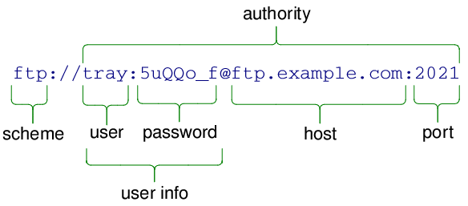

The *authority* data is interpreted according to *mode*: in StrictMode, any '%' characters must be followed by exactly two hexadecimal characters and some characters (including space) are not allowed in undecoded form. In TolerantMode (the default), all characters are accepted in undecoded form and the tolerant parser will correct stray '%' not followed by two hex characters.

This function does not allow *mode* to be QUrl::DecodedMode. To set fully decoded data, call setUserName(), setPassword(), setHost() and setPort() individually.

**See also** authority(), setUserInfo(), setHost(), and setPort().

### void QUrl::setFragment(const QString &*fragment*, QUrl::ParsingMode *mode* = TolerantMode)

Sets the fragment of the URL to *fragment*. The fragment is the last part of the URL, represented by a '#' followed by a string of characters. It is typically used in HTTP for referring to a certain link or point on a page:

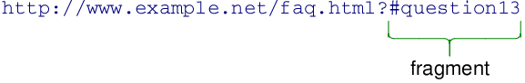

The fragment is sometimes also referred to as the URL "reference".

Passing an argument of QString() (a null QString) will unset the fragment. Passing an argument of QString("") (an empty but not null QString) will set the fragment to an empty string (as if the original URL had a lone "#").

The *fragment* data is interpreted according to *mode*: in StrictMode, any '%' characters must be followed by exactly two hexadecimal characters and some characters (including space) are not allowed in undecoded form. In TolerantMode, all characters are accepted in undecoded form and the tolerant parser will correct stray '%' not followed by two hex characters. In DecodedMode, '%' stand for themselves and encoded characters are not possible.

QUrl::DecodedMode should be used when setting the fragment from a data source which is not a URL or with a fragment obtained by calling fragment() with the QUrl::FullyDecoded formatting option.

**See also** fragment() and hasFragment().

### void QUrl::setHost(const QString &*host*, QUrl::ParsingMode *mode* = DecodedMode)

Sets the host of the URL to *host*. The host is part of the authority.

The *host* data is interpreted according to *mode*: in StrictMode, any '%' characters must be followed by exactly two hexadecimal characters and some characters (including space) are not allowed in undecoded form. In TolerantMode, all characters are accepted in undecoded form and the tolerant parser will correct stray '%' not followed by two hex characters. In DecodedMode, '%' stand for themselves and encoded characters are not possible.

Note that, in all cases, the result of the parsing must be a valid hostname according to STD 3 rules, as modified by the Internationalized Resource Identifiers specification (RFC 3987). Invalid hostnames are not permitted and will cause isValid() to become false.

**See also** host() and setAuthority().

### `[static]`void QUrl::setIdnWhitelist(const QStringList &*list*)

Sets the whitelist of Top-Level Domains (TLDs) that are allowed to have non-ASCII characters in domains to the value of *list*.

Note that if you call this function, you need to do so *before* you start any threads that might access idnWhitelist().

Qt comes with a default list that contains the Internet top-level domains that have published support for Internationalized Domain Names (IDNs) and rules to guarantee that no deception can happen between similarly-looking characters (such as the Latin lowercase letter `'a'` and the Cyrillic equivalent, which in most fonts are visually identical).

This list is periodically maintained, as registrars publish new rules.

This function is provided for those who need to manipulate the list, in order to add or remove a TLD. It is not recommended to change its value for purposes other than testing, as it may expose users to security risks.

**See also** idnWhitelist().

### void QUrl::setPassword(const QString &*password*, QUrl::ParsingMode *mode* = DecodedMode)

Sets the URL's password to *password*. The *password* is part of the user info element in the authority of the URL, as described in setUserInfo().

The *password* data is interpreted according to *mode*: in StrictMode, any '%' characters must be followed by exactly two hexadecimal characters and some characters (including space) are not allowed in undecoded form. In TolerantMode, all characters are accepted in undecoded form and the tolerant parser will correct stray '%' not followed by two hex characters. In DecodedMode, '%' stand for themselves and encoded characters are not possible.

QUrl::DecodedMode should be used when setting the password from a data source which is not a URL, such as a password dialog shown to the user or with a password obtained by calling password() with the QUrl::FullyDecoded formatting option.

**See also** password() and setUserInfo().

### void QUrl::setPath(const QString &*path*, QUrl::ParsingMode *mode* = DecodedMode)

Sets the path of the URL to *path*. The path is the part of the URL that comes after the authority but before the query string.

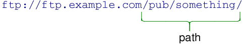

For non-hierarchical schemes, the path will be everything following the scheme declaration, as in the following example:

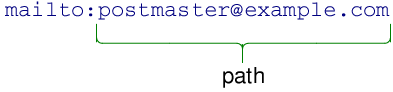

The *path* data is interpreted according to *mode*: in StrictMode, any '%' characters must be followed by exactly two hexadecimal characters and some characters (including space) are not allowed in undecoded form. In TolerantMode, all characters are accepted in undecoded form and the tolerant parser will correct stray '%' not followed by two hex characters. In DecodedMode, '%' stand for themselves and encoded characters are not possible.

QUrl::DecodedMode should be used when setting the path from a data source which is not a URL, such as a dialog shown to the user or with a path obtained by calling path() with the QUrl::FullyDecoded formatting option.

**See also** path().

### void QUrl::setPort(int *port*)

Sets the port of the URL to *port*. The port is part of the authority of the URL, as described in setAuthority().

*port* must be between 0 and 65535 inclusive. Setting the port to -1 indicates that the port is unspecified.

**See also** port().

### void QUrl::setQuery(const QString &*query*, QUrl::ParsingMode *mode* = TolerantMode)

Sets the query string of the URL to *query*.

This function is useful if you need to pass a query string that does not fit into the key-value pattern, or that uses a different scheme for encoding special characters than what is suggested by QUrl.

Passing a value of QString() to *query* (a null QString) unsets the query completely. However, passing a value of QString("") will set the query to an empty value, as if the original URL had a lone "?".

The *query* data is interpreted according to *mode*: in StrictMode, any '%' characters must be followed by exactly two hexadecimal characters and some characters (including space) are not allowed in undecoded form. In TolerantMode, all characters are accepted in undecoded form and the tolerant parser will correct stray '%' not followed by two hex characters. In DecodedMode, '%' stand for themselves and encoded characters are not possible.

Query strings often contain percent-encoded sequences, so use of DecodedMode is discouraged. One special sequence to be aware of is that of the plus character ('+'). QUrl does not convert spaces to plus characters, even though HTML forms posted by web browsers do. In order to represent an actual plus character in a query, the sequence "%2B" is usually used. This function will leave "%2B" sequences untouched in TolerantMode or StrictMode.

**See also** query() and hasQuery().

### `[since 5.0]`void QUrl::setQuery(const QUrlQuery &*query*)

This is an overloaded function.

Sets the query string of the URL to *query*.

This function reconstructs the query string from the QUrlQuery object and sets on this QUrl object. This function does not have parsing parameters because the QUrlQuery contains data that is already parsed.

This function was introduced in Qt 5.0.

**See also** query() and hasQuery().

### void QUrl::setScheme(const QString &*scheme*)

Sets the scheme of the URL to *scheme*. As a scheme can only contain ASCII characters, no conversion or decoding is done on the input. It must also start with an ASCII letter.

The scheme describes the type (or protocol) of the URL. It's represented by one or more ASCII characters at the start the URL.

A scheme is strictly [RFC 3986](https://datatracker.ietf.org/doc/html/rfc3986)-compliant: `scheme = ALPHA *( ALPHA / DIGIT / "+" / "-" / "." )`

The following example shows a URL where the scheme is "ftp":

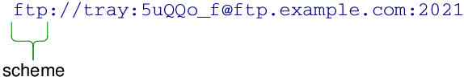

To set the scheme, the following call is used:

```
    QUrl url;
    url.setScheme("ftp");
```

The scheme can also be empty, in which case the URL is interpreted as relative.

**See also** scheme() and isRelative().

### void QUrl::setUrl(const QString &*url*, QUrl::ParsingMode *parsingMode* = TolerantMode)

Parses *url* and sets this object to that value. QUrl will automatically percent encode all characters that are not allowed in a URL and decode the percent-encoded sequences that represent an unreserved character (letters, digits, hyphens, underscores, dots and tildes). All other characters are left in their original forms.

Parses the *url* using the parser mode *parsingMode*. In TolerantMode (the default), QUrl will correct certain mistakes, notably the presence of a percent character ('%') not followed by two hexadecimal digits, and it will accept any character in any position. In StrictMode, encoding mistakes will not be tolerated and QUrl will also check that certain forbidden characters are not present in unencoded form. If an error is detected in StrictMode, isValid() will return false. The parsing mode DecodedMode is not permitted in this context and will produce a run-time warning.

**See also** url() and toString().

### void QUrl::setUserInfo(const QString &*userInfo*, QUrl::ParsingMode *mode* = TolerantMode)

Sets the user info of the URL to *userInfo*. The user info is an optional part of the authority of the URL, as described in setAuthority().

The user info consists of a user name and optionally a password, separated by a ':'. If the password is empty, the colon must be omitted. The following example shows a valid user info string:

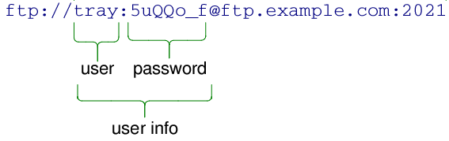

The *userInfo* data is interpreted according to *mode*: in StrictMode, any '%' characters must be followed by exactly two hexadecimal characters and some characters (including space) are not allowed in undecoded form. In TolerantMode (the default), all characters are accepted in undecoded form and the tolerant parser will correct stray '%' not followed by two hex characters.

This function does not allow *mode* to be QUrl::DecodedMode. To set fully decoded data, call setUserName() and setPassword() individually.

**See also** userInfo(), setUserName(), setPassword(), and setAuthority().

### void QUrl::setUserName(const QString &*userName*, QUrl::ParsingMode *mode* = DecodedMode)

Sets the URL's user name to *userName*. The *userName* is part of the user info element in the authority of the URL, as described in setUserInfo().

The *userName* data is interpreted according to *mode*: in StrictMode, any '%' characters must be followed by exactly two hexadecimal characters and some characters (including space) are not allowed in undecoded form. In TolerantMode (the default), all characters are accepted in undecoded form and the tolerant parser will correct stray '%' not followed by two hex characters. In DecodedMode, '%' stand for themselves and encoded characters are not possible.

QUrl::DecodedMode should be used when setting the user name from a data source which is not a URL, such as a password dialog shown to the user or with a user name obtained by calling userName() with the QUrl::FullyDecoded formatting option.

**See also** userName() and setUserInfo().

### void QUrl::swap(QUrl &*other*)

Swaps URL *other* with this URL. This operation is very fast and never fails.

### `[static]`QByteArray QUrl::toAce(const QString &*domain*)

Returns the ASCII Compatible Encoding of the given domain name *domain*. The result of this function is considered equivalent to *domain*.

The ASCII-Compatible Encoding (ACE) is defined by RFC 3490, RFC 3491 and RFC 3492. It is part of the Internationalizing Domain Names in Applications (IDNA) specification, which allows for domain names (like `"example.com"`) to be written using international characters.

This function returns an empty QByteArray if *domain* is not a valid hostname. Note, in particular, that IPv6 literals are not valid domain names.

### `[since 5.2]`CFURLRef QUrl::toCFURL() const

Creates a CFURL from a QUrl.

The caller owns the CFURL and is responsible for releasing it.

This function was introduced in Qt 5.2.

### `[since 5.0]`QString QUrl::toDisplayString(QUrl::FormattingOptions *options* = FormattingOptions(PrettyDecoded)) const

Returns a human-displayable string representation of the URL. The output can be customized by passing flags with *options*. The option RemovePassword is always enabled, since passwords should never be shown back to users.

With the default options, the resulting QString can be passed back to a QUrl later on, but any password that was present initially will be lost.

This function was introduced in Qt 5.0.

**See also** FormattingOptions, toEncoded(), and toString().

### QByteArray QUrl::toEncoded(QUrl::FormattingOptions *options* = FullyEncoded) const

Returns the encoded representation of the URL if it's valid; otherwise an empty QByteArray is returned. The output can be customized by passing flags with *options*.

The user info, path and fragment are all converted to UTF-8, and all non-ASCII characters are then percent encoded. The host name is encoded using Punycode.

### QString QUrl::toLocalFile() const

Returns the path of this URL formatted as a local file path. The path returned will use forward slashes, even if it was originally created from one with backslashes.

If this URL contains a non-empty hostname, it will be encoded in the returned value in the form found on SMB networks (for example, "//servername/path/to/file.txt").

```
    qDebug() << QUrl("file:file.txt").toLocalFile();            // "file.txt"
    qDebug() << QUrl("file:/home/user/file.txt").toLocalFile(); // "/home/user/file.txt"
    qDebug() << QUrl("file.txt").toLocalFile();                 // ""; wasn't a local file as it had no scheme
```

Note: if the path component of this URL contains a non-UTF-8 binary sequence (such as %80), the behaviour of this function is undefined.

**See also** fromLocalFile() and isLocalFile().

### `[since 5.2]`NSURL *QUrl::toNSURL() const

Creates a NSURL from a QUrl.

The NSURL is autoreleased.

This function was introduced in Qt 5.2.

### `[static]`QByteArray QUrl::toPercentEncoding(const QString &*input*, const QByteArray &*exclude* = QByteArray(), const QByteArray &*include* = QByteArray())

Returns an encoded copy of *input*. *input* is first converted to UTF-8, and all ASCII-characters that are not in the unreserved group are percent encoded. To prevent characters from being percent encoded pass them to *exclude*. To force characters to be percent encoded pass them to *include*.

Unreserved is defined as: `ALPHA / DIGIT / "-" / "." / "_" / "~"`

```
QByteArray ba = QUrl::toPercentEncoding("{a fishy string?}", "{}", "s");
qDebug(ba.constData());
// prints "{a fi%73hy %73tring%3F}"
```

### QString QUrl::toString(QUrl::FormattingOptions *options* = FormattingOptions(PrettyDecoded)) const

Returns a string representation of the URL. The output can be customized by passing flags with *options*. The option QUrl::FullyDecoded is not permitted in this function since it would generate ambiguous data.

The default formatting option is PrettyDecoded.

**See also** FormattingOptions, url(), and setUrl().

### `[static, since 5.1]`QStringList QUrl::toStringList(const QList<QUrl> &*urls*, QUrl::FormattingOptions *options* = FormattingOptions(PrettyDecoded))

Converts a list of *urls* into a list of QString objects, using toString(*options*).

This function was introduced in Qt 5.1.

### QString QUrl::url(QUrl::FormattingOptions *options* = FormattingOptions(PrettyDecoded)) const

Returns a string representation of the URL. The output can be customized by passing flags with *options*. The option QUrl::FullyDecoded is not permitted in this function since it would generate ambiguous data.

The resulting QString can be passed back to a QUrl later on.

Synonym for toString(options).

**See also** setUrl(), FormattingOptions, toEncoded(), and toString().

### QString QUrl::userInfo(QUrl::ComponentFormattingOptions *options* = PrettyDecoded) const

Returns the user info of the URL, or an empty string if the user info is undefined.

This function returns an unambiguous value, which may contain that characters still percent-encoded, plus some control sequences not representable in decoded form in QString.

The *options* argument controls how to format the user info component. The value of QUrl::FullyDecoded is not permitted in this function. If you need to obtain fully decoded data, call userName() and password() individually.

**See also** setUserInfo(), userName(), password(), and authority().

### QString QUrl::userName(QUrl::ComponentFormattingOptions *options* = FullyDecoded) const

Returns the user name of the URL if it is defined; otherwise an empty string is returned.

The *options* argument controls how to format the user name component. All values produce an unambiguous result. With QUrl::FullyDecoded, all percent-encoded sequences are decoded; otherwise, the returned value may contain some percent-encoded sequences for some control sequences not representable in decoded form in QString.

Note that QUrl::FullyDecoded may cause data loss if those non-representable sequences are present. It is recommended to use that value when the result will be used in a non-URL context, such as setting in QAuthenticator or negotiating a login.

**See also** setUserName() and userInfo().

### bool QUrl::operator!=(const QUrl &*url*) const

Returns `true` if this URL and the given *url* are not equal; otherwise returns `false`.

**See also** matches().

### bool QUrl::operator==(const QUrl &*url*) const

Returns `true` if this URL and the given *url* are equal; otherwise returns `false`.

**See also** matches().

## Related Non-Members

### QDataStream &operator<<(QDataStream &*out*, const QUrl &*url*)

Writes url *url* to the stream *out* and returns a reference to the stream.

**See also** Format of the QDataStream operators.

### QDataStream &operator>>(QDataStream &*in*, QUrl &*url*)

Reads a url into *url* from the stream *in* and returns a reference to the stream.

**See also** Format of the QDataStream operators.

## Macro Documentation

### QT_NO_URL_CAST_FROM_STRING

Disables automatic conversions from QString (or char *) to QUrl.

Compiling your code with this define is useful when you have a lot of code that uses QString for file names and you wish to convert it to use QUrl for network transparency. In any code that uses QUrl, it can help avoid missing QUrl::resolved() calls, and other misuses of QString to QUrl conversions.

For example, if you have code like

```
url = filename; // probably not what you want
```

you can rewrite it as

```
url = QUrl::fromLocalFile(filename);
url = baseurl.resolved(QUrl(filename));
```

**See also** QT_NO_CAST_FROM_ASCII.

© The Qt Company Ltd  
Licensed under the GNU Free Documentation License, Version 1.3.  
https://doc.qt.io/qt-6.2/qurl.html